# Labor Market

Session 1

Luis F. Gómez L.

luis.gomezl@unimilitar.edu.co

Distance Learning Faculty

11 February, 2026

# Please Read Me

- Check the message **Welcome greeting** published in Announcements forum.
- Dear student please edit your profile uploading a photo where your face is clearly visible.
- If you want to participate, please fill out the following survey: **Primer corte 30% > Learning Activities > Tu opinión sobre la economía colombiana**
- This presentation is based on (Cardenas, 2020, Chapter 9)
- **Purpose**
  - Examine the evolution and characteristics of the supply and demand of labor in Colombia

# Labor classification of the population

- To understand the indicators of the labor market from an economic perspective, it is necessary to classify the population from a labor point of view. Initially, the total population of a territory could be included but in practice the **Total Population (TP)** that is included **doesn’t** cover (Hussmanns et al., 1990, Chapter 2):
  - Members of the armed forces because this information is considered secret or because it is not easy to obtain information when its members are in barracks and military areas.
  - Residents in institutions such as people who are not part of the military forces but reside in military facilities, residents of penal or correctional centers and hospital residents.
- In that sense, the **Total Population (TP)** covers the non-institutional civilian population residing in households.

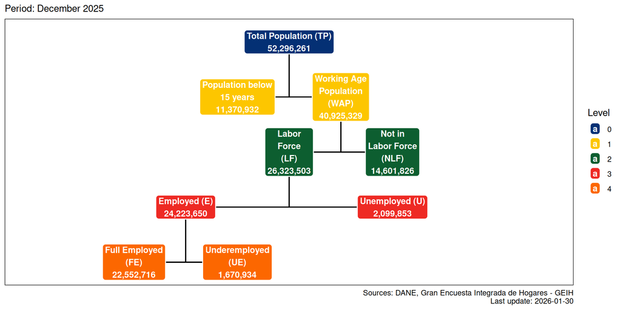

Figure 1: Labor classification of the population in Colombia

# Labor market indicators

- **Percentage of the working age population** (“Porcentaje de población en edad de trabajar”)
  - $\%WAP = \frac{WAP}{PT} \times 100$
- **Labor participation rate (LPR)** (“Tasa global de participación”)
  - $LPR = \frac{LF}{WAP} \times 100$
- **Employment rate (ER)** (“Tasa de ocupación”)
  - $ER = \frac{E}{WAP} \times 100$
- **Unemployment rate (UR)** (“Tasa de desempleo”)
  - $UR = \frac{U}{LF} \times 100$
- **Underemployment (UER)** (“Tasa de subempleo”)
  - $UER = \frac{UE}{LF} \times 100$

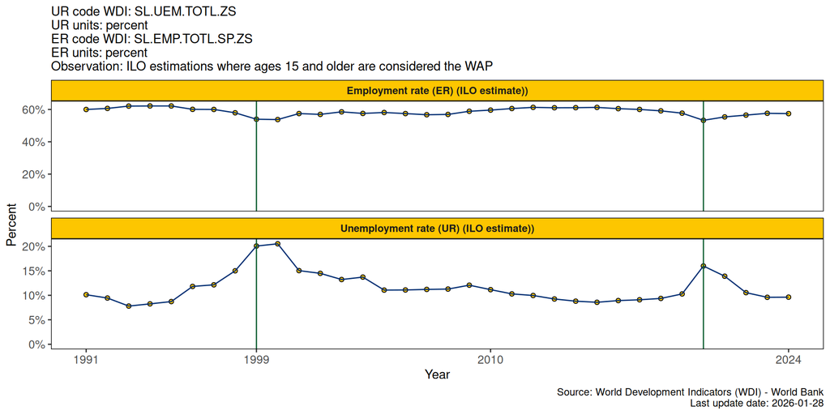

Figure 2: Annual Unemployment rate (UR) and Employment rate (ER) in Colombia

# Labor demand

- The labor demand is the process by which the economy generates job vacancies
- How companies decide how many workers to contract?
  - Demand of the products that offer by the company
  - Wages (the price of labor)
  - Labor regulation
  - The costs of other inputs different form labor and used in production
  - The technology used by companies

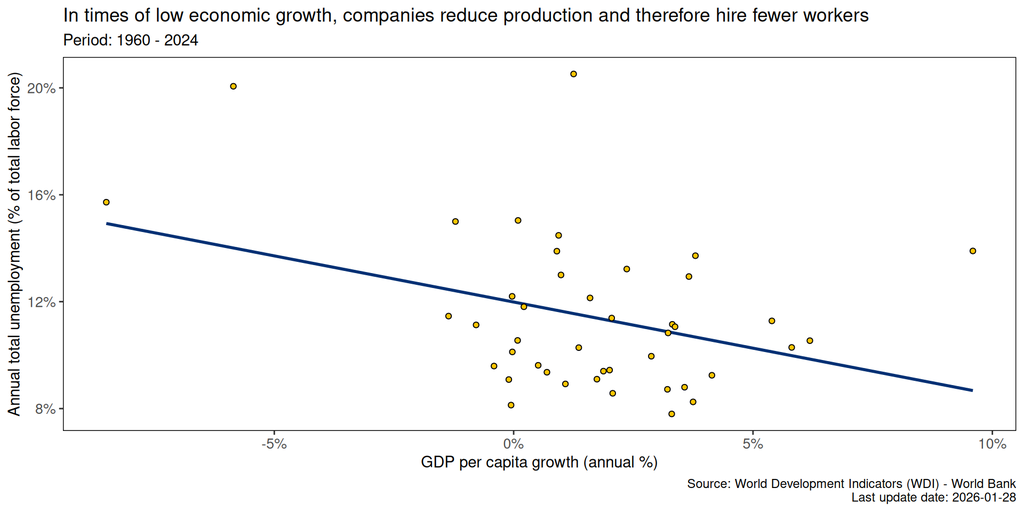

Figure 3: Economic growth vs unemployment rate

# Wages

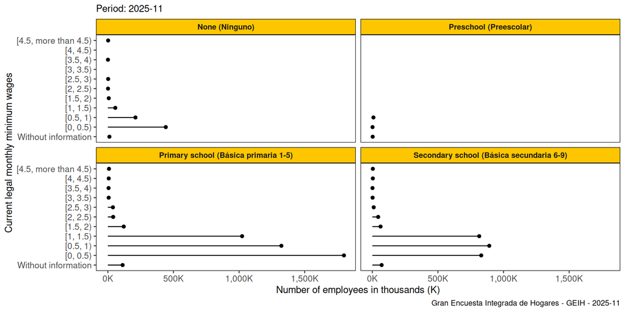

Figure 4: Employed population according to last educational degree obtained and income bracket

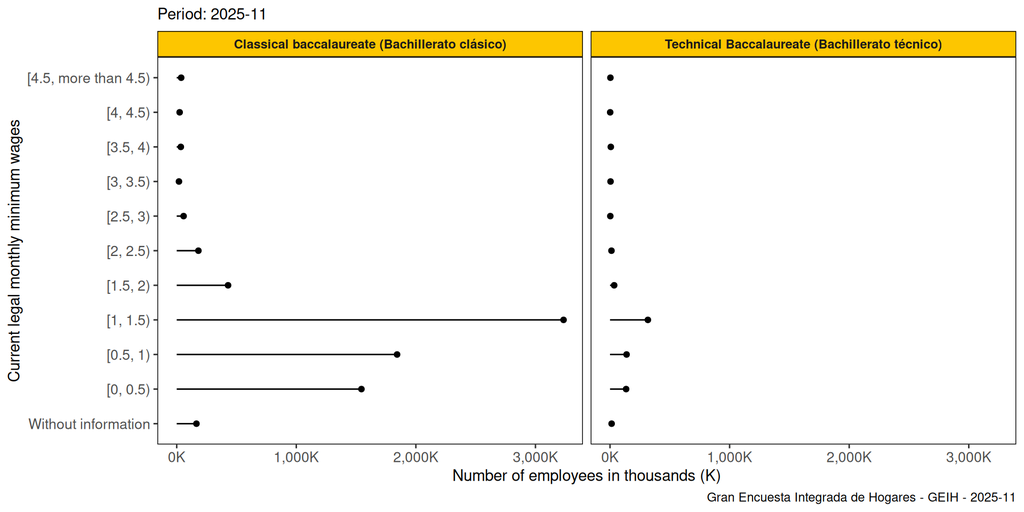

Figure 5: Employed population according to last educational degree obtained and income bracket

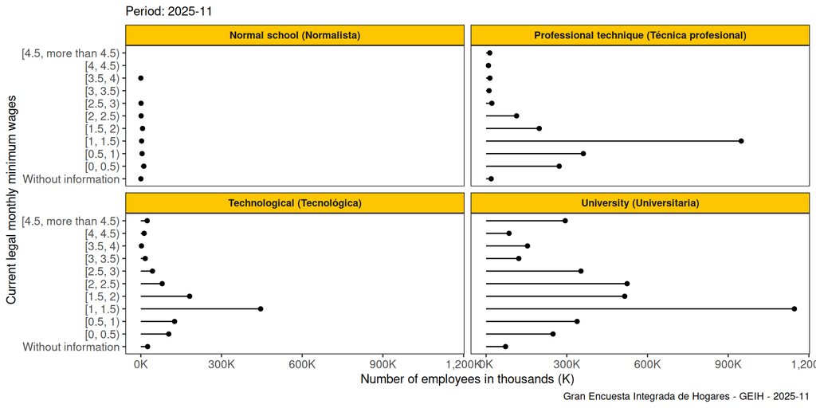

Figure 6: Employed population according to last educational degree obtained and income bracket

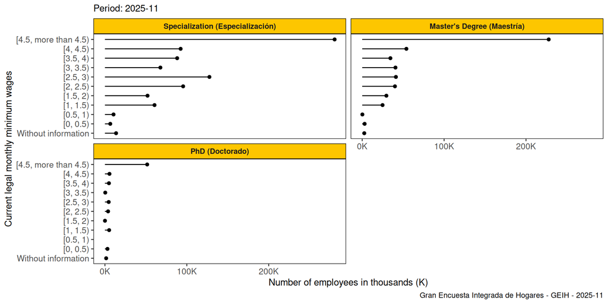

Figure 7: Employed population according to last educational degree obtained and income bracket

- Mincer equation
  - $log_e(w_{it}) = log_e(w_o) + \beta_1Ed_{it} + \beta_2Ex_{it} + \beta_2Ex_{it}^2 + \epsilon_{it}$
    - $log_e$: natural logarithm
    - $w_{it}$: wage of individual $i$ in period $t$
    - $w_o$: wage without any level of education an experience
    - $\epsilon_{it}$: years of education of individual $i$ in period $t$
    - $Ex_{it}$: potential experience of individual $i$ in period $t$ which is equal to the age minus the years of education minus six
    - $\epsilon_{it}$: are other components of individual $i$ in period $t$ that might affect the wage

# Labor regulation

- The labor regulation refers to:
  - The laws governing labor contracts
  - Laws governing labor relations that empower unions to represent workers collectively
  - Social security laws governing the response to social needs such as unemployment, maternity, old age, disability, death and sickness
- Resources
  - **Calculadora Laboral - Mintrabajo**
    - https://www.mintrabajo.gov.co/web/guest/inicio > Atención al Ciudadano > Trámites y Servicios > Mi Calculadora

# Acknowledgments

- To my family that supports me
- To the taxpayers of Colombia and the [**UMNG students**](https://www.umng.edu.co/estudiante) who pay my salary
- To the [**Business Science**](https://www.business-science.io/) and [**R4DS Online Learning**](https://www.rfordatasci.com/) communities where I learn [**R**](https://www.r-project.org/about.html) and [**$\pi$-thon**](https://www.python.org/about/)
- To the [**R Core Team**](https://www.r-project.org/contributors.html), the creators of [**RStudio IDE**](https://posit.co/download/rstudio-desktop/), [**Positron**](https://positron.posit.co/), [**Quarto**](https://quarto.org/) and the authors and maintainers of the packages [**tidyverse**](https://CRAN.R-project.org/package=tidyverse), [**scales**](https://CRAN.R-project.org/package=scales), [**readxl**](https://CRAN.R-project.org/package=readxl), [**wbstats**](https://CRAN.R-project.org/package=wbstats) and [**tinytex**](https://CRAN.R-project.org/package=tinytex) for allowing me to access these tools without paying for a license

# References

Cardenas, M. (2020). *Introducción a la Economía Colombiana* (4th ed.). Alfaomega.

Hussmanns, R., Mehran, F., & Varmā, V. (1990). *Surveys of economically active population, employment, unemployment, and underemployment: An ILO manual on concepts and methods*. International Labour Office. https://www.ilo.org/global/statistics-and-databases/publications/WCMS_215885/lang--en/index.htm